# Confidence intervals for Bernoulli samples

Empirical exploration of the sizes of two Bernoulli confidence intervals.

In Larry Wasserman’s *All of Nonparametric Statistics*, the following example occurs when discussing different kinds of confidence sets:

Let $X_1,\dots,X_n\sim\text{Bernoulli}(p)$. Then a *pointwise asymptotic* $1-\alpha$ confidence interval is given by

$$\hat p_n \pm z_{\alpha/2}\sqrt{\frac{\hat p_n(1-\hat p_n)}{n}}$$

and a *finite sample* confidence interval is given by (using Hoeffding’s inequality)

$$\hat p_n\pm\sqrt{\frac{1}{2n}\log\left(\frac{2}{\alpha}\right)}$$

The distinction between pointwise asymptotic and finite sample confidence intervals is rooted in using a statistical model: a statistical model $\mathfrak F$ is some collection of distribution functions.

A confidence interval $C_n$ is a *finite sample* confidence interval if

$$\inf_{F\in\mathfrak F}\mathbb{P}(\theta\in C_n) \geq 1-\alpha$$

and it is a *pointwise asymptotic* confidence interval if for every $F\in\mathfrak F$,

$$\liminf_{n\to\infty}\mathbb{P}(\theta\in C_n)\geq 1-\alpha$$

The pointwise asymptotic intervals actually depend on which distribution function $F\in\mathfrak F$ is the “correct one”, while the finite sample intervals optimize over all possible distribution functions. Appropriate sample sizes to actually get far enough along the limit (in a pointwise asymptotic interval) depend on this “correct” $F$, and thus cannot usually be known when using it.

## Comparing confidence intervals

Seeing this laid out for me immediately inspired the question: which confidence interval in this Bernoulli example is narrower? Are we sacrificing precision for theoretical soundness when using the finite sample confidence interval? What are the implicit tradeoffs here?

So let’s have a look at it, using simulation!

```r
alpha = 0.05
ci.pa = function(X) {
  p = mean(X)
  w = qnorm(1-alpha/2)*sqrt(p*(1-p)/length(X))
  data.frame(lo=p-w, hi=p+w)
}
ci.fs = function(X) {
  p = mean(X)
  w = sqrt(log(2/alpha)/(2*length(X)))
  data.frame(lo=p-w, hi=p+w)
}
```

For our simulation, we shall generate a lot of Bernoulli draws from different distributions, and record the interval width `hi-lo` for each case.

```r
N.sim = 1000
sample.sizes = c(5,10,50,100)

sim = do.call(rbind, lapply(1:N.sim, function(n) {
  inner.sim = do.call(rbind, lapply(sample.sizes, function(ss) {
    p = runif(1)
    draws = rbernoulli(ss, p=p)
    i.pa = ci.pa(draws)
    i.fs = ci.fs(draws)
    w.pa = i.pa$hi-i.pa$lo
    w.fs = i.fs$hi-i.fs$lo
    data.frame(ss=ss, pa=w.pa, fs=w.fs)
  }))
  data.frame(sample.size=inner.sim$ss,
             width.pa=inner.sim$pa,
             width.fs=inner.sim$fs)
}))
```

Now that we have all these confidence interval widths, let’s look at how they distribute.

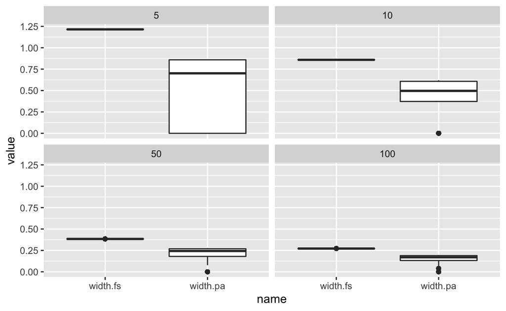

```r
sim %>%
  pivot_longer(c(width.pa, width.fs)) %>%
  gf_boxplot(value ~ name | sample.size)
```

A few observations here. First off - and with no real surprise - the finite sample confidence interval widths do not change within a sample size. This is (once you think of it) because the estimator itself plays no role in creating the confidence interval width. A second observation is that the width of the confidence interval is consistently smaller pointwise asymptotic case.

So there is, indeed, a trade-off between quality of the confidence interval (pointwise asymptotic vs. finite sample) and width of the confidence interval. By using the pointwise asymptotic version, we get a higher theoretical uncertainty in our results - appropriate sample sizes for a specific application depend on the true and unknown value of $p$ - but we do get more precise confidence intervals out of the bargain.